# MD exercises Round 2

March 12, 2017

# Barplots

## Distribution of one categorical variable

When working with a qualitative variable (one in which the data falls into many different categories), the first plot you will likely make is a barplot. This will show how many of each category there are for that particular categorical variable.

Recall the `bechdel` data frame that was introduced earlier in the course from the `fivethirtyeight` R package. We will load into the environment here.

```r
library(fivethirtyeight)
library(ggplot2)
library(dplyr)
data(bechdel)
```

Suppose we are interested in analyzing the distribution of the `clean_test` variable.

Observe and reflect on the The Bechdel Test Over Time image in the article “The Dollar-And-Cents Case Against Hollywood’s Exclusion of Women” (https://fivethirtyeight.com/features/the-dollar-and-cents-case-against-hollywoods-exclusion-of-women/). You can use this to get a better idea as to what the categories of `clean_test` represent.

To assist with the plotting, the `clean_test` variable has been converted to a factor with levels set corresponding to the order given in the plot in the article.

```r
# Convert to factor
bechdel$clean_test <- factor(bechdel$clean_test, ordered = TRUE,
    levels = c("nowomen", "notalk", "men", "dubious", "ok"))
```

Instructions

- Produce an appropriate plot looking at the distribution of clean_test in the bechdel data frame.

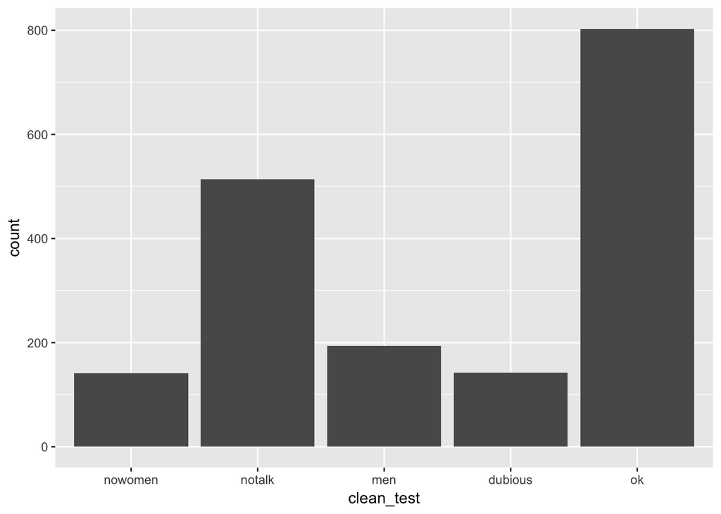

```r
# Produce an appropriate plot by filling in the entries correctly (and removing the "#" commenting out the following lines).
ggplot(data = bechdel,
       mapping = aes( x = clean_test)) +
  geom_bar()
```

## Distribution of another categorical variable

The plot in the previous exercise is a little deceiving since it appears that ok stands above the other categories. There is a different variable in bechdel that better shows whether a movie passed or failed the Bechdel test.

Instructions

- Use the glimpse function on bechdel to identify this more appropriate variable. (Recall that you can test code in the R Console first, then enter it into your script when you are happy with it.)
- Produce a barplot of this variable and also fill based on the different values of the variable.

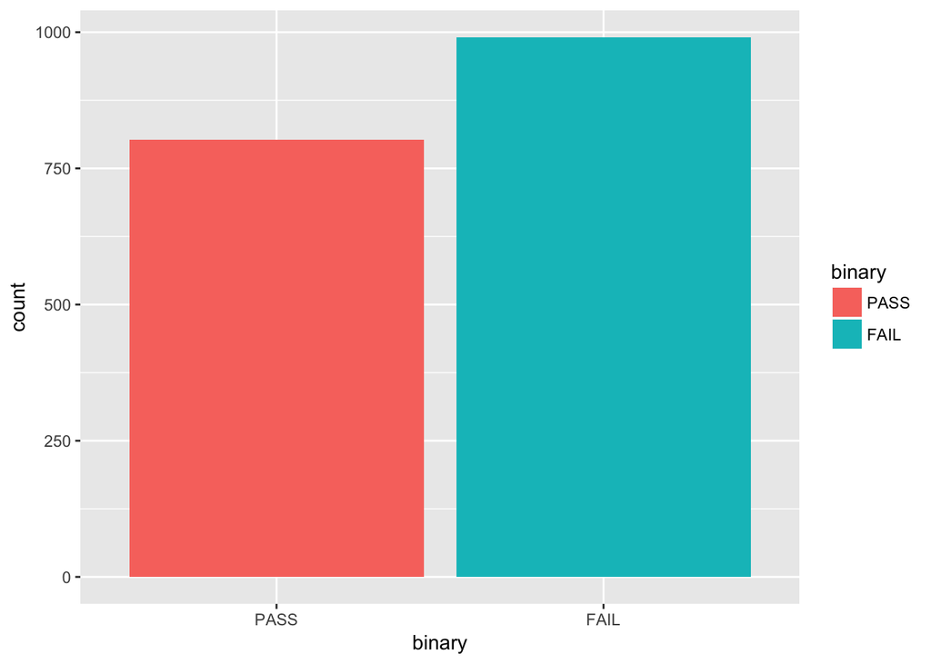

```r
# Identify the variable that gives pass/fail of the Bechdel test
# library( )

# at first factoring pass and fail
bechdel$binary <- factor(bechdel$binary, ordered = TRUE,
    levels = c("PASS","FAIL"))

# Produce an appropriate plot by filling in the entries correctly
library(ggplot2)
ggplot(data = bechdel,
        mapping = aes( x = binary, fill = binary)) +
                geom_bar()
```

## Movies over time

The Bechdel Test Over Time image in the article “The Dollar-And-Cents Case Against Hollywood’s Exclusion of Women” breaks down the distribution of `clean_test` across five year intervals from 1970 to 2014 (1970-’74, 1975-’79, etc.). Technically, the last interval only contains four years: 2010-’13.

We will start by adding a variable `five_year` to the dataset that will break down the data into the five year intervals mentioned above. Note: these intervals are denoted by the year at the start of the interval.

```r
bechdel <- bechdel %>%
  mutate(five_year = 1970+5*floor((year-1970)/5)) %>%
  mutate(five_year = factor(as.character(five_year),ordered = TRUE, levels = c("1970", "1975", "1980", "1985", "1990","1995","2000","2005","2010")))
```

Instructions

- Produce a barplot showing the counts of the number of movies where the years are grouped into the 5 year increments stored in `five_year`.

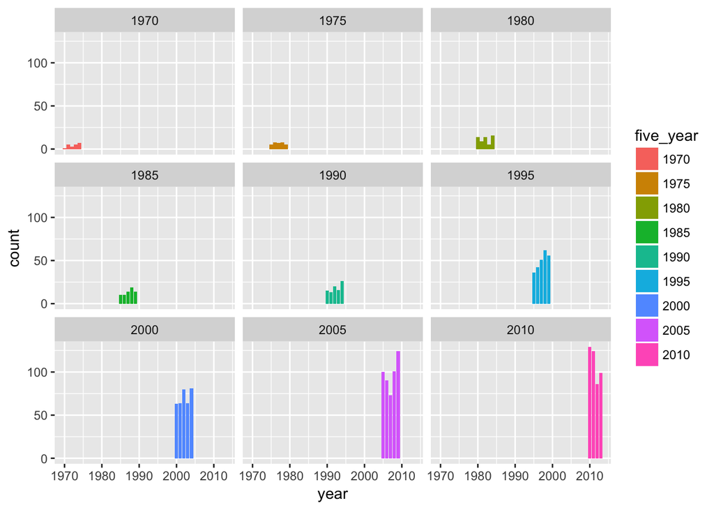

```r
ggplot(data = bechdel, mapping = aes(x = year, fill = five_year)) +
        geom_bar() +
        facet_wrap(~five_year)
```

## Bechdel pass/fail over time (stacked)

We can now look at the relationship of movies passing or failing the Bechdel test based on the `five_year` time periods. In other words, we will be “painting” the bars you created in the previous exercise proportionally based on the number that `FAIL` or `PASS`.

Instructions:

- Produce a barplot showing the counts of the number of movies in each of the different `five_year` increments filled according to the levels of binary.

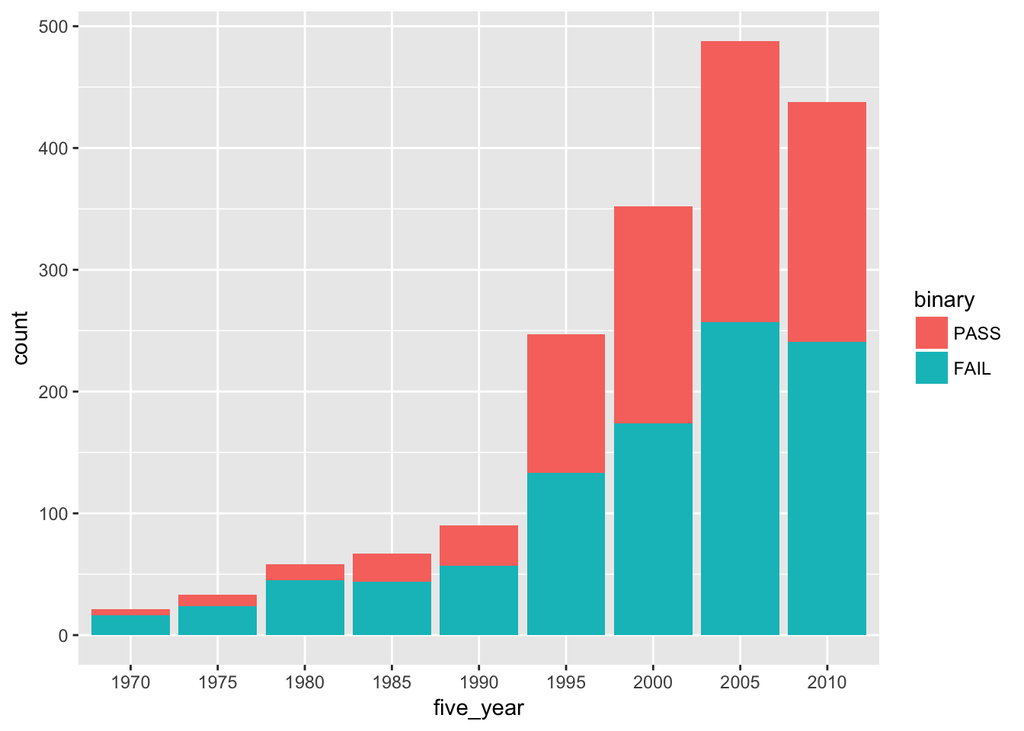

```r
ggplot(data = bechdel, mapping = aes(x = five_year, fill = binary)) +
        geom_bar()
```

Instructions:

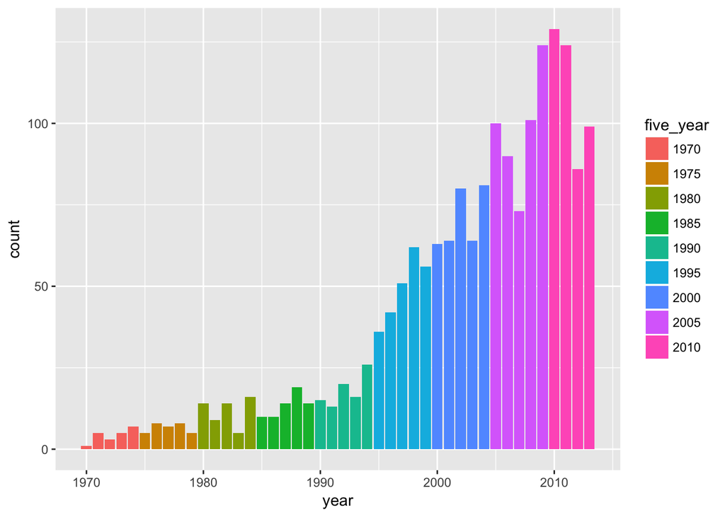

```r
ggplot(data = bechdel, mapping = aes(x = year, fill = five_year)) +
        geom_bar(position = "dodge")
```

## Bechdel pass/fail over time (faceted)

We can also create separate plots for FAIL and PASS using the concept of “small multiples.”

Instructions:

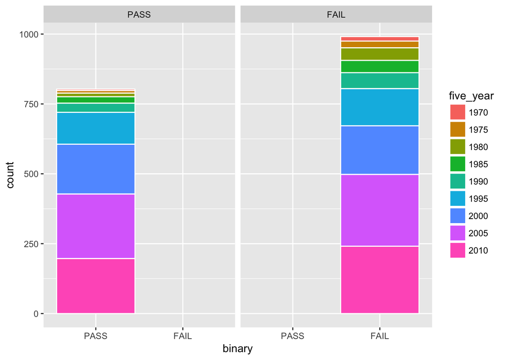

```r
ggplot(data = bechdel, mapping = aes(x = binary, fill = five_year)) +
        geom_bar(color = "white") +
        facet_wrap(~ binary)
```

## Bechdel pass/fail over time (proportional height)

Each of the last three plots have the common problem that raw counts are shown instead of the proportion of FAIL versus PASS for each `five_year` increment. While there are circumstances where raw counts make sense, this Bechdel test example leads us to want to explore the percentages of FAIL versus PASS instead.

Instructions:

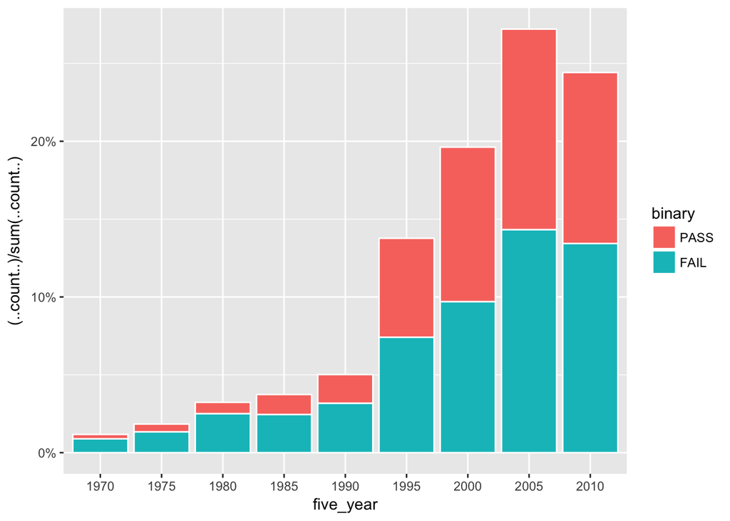

```r
# creating a variable which calculates the percentage for Y-axis
ggplot(data = bechdel, mapping = aes(x = five_year, fill = binary)) +
        geom_bar(aes(y = (..count..)/sum(..count..)), color = "white") +
        scale_y_continuous(labels = scales::percent)
```

## Showing off

We could continue to tweak the plot to make it look more and more like the actual published plot using nothing but ggplot code. This is one of the great powers of R: its customizability and portability make creating professional-style graphics interactive, fun, and REPRODUCIBLE!

Instructions:

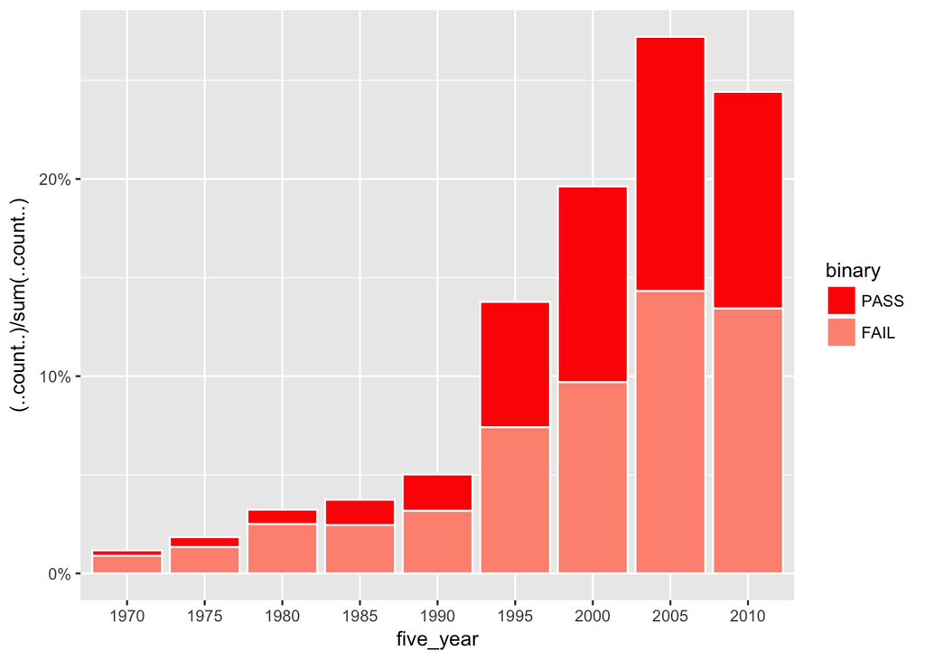

```r
# Add these lines at the end of your ggplot code
# These will color the bars in the same colors as the FiveThirtyEight plot
# (Note the placement of the + here to be added on to your code.)
#                                    +
# scale_fill_manual(values = c("#FF2603", "#FF937F", "#FEC9C3", "#6AB4DA", "#018ED5"))
ggplot(data = bechdel, mapping = aes(x = five_year, fill = binary)) +
        geom_bar(aes(y = (..count..)/sum(..count..)), color = "white") +
        scale_y_continuous(labels = scales::percent) +
        scale_fill_manual(values = c("#FF2603", "#FF937F", "#FEC9C3", "#6AB4DA", "#018ED5"))
```

# ggplot2 review

## Fixing an inappropriate plot for one variable

When one doesn’t properly use the correct plot based on the type of variables, some pretty strange plots can be produced. These plots are hard to interpret and often extremely ineffective at telling a story about the data. This exercise and the ones that follow will have you examine why a plot is incorrect and/or fix incorrect code to make a more appropriate plot.

Read over the 2014 article from FiveThirtyEight.com entitled “The Economic Guide To Picking A College Major” (https://fivethirtyeight.com/features/the-economic-guide-to-picking-a-college-major/). You can find the data corresponding to the story as `college_all_ages` in the `fivethirtyeight` R package. We are interested in looking at the distribution of the `unemployment_rate` variable in this `college_all_ages` data frame.

Instructions:

- Fix the code given to produce an appropriate plot looking at how unemployment_rate varies in the college_all_ages data frame.
- Make sure to also use the color = “white” argument to better clarify your plot.

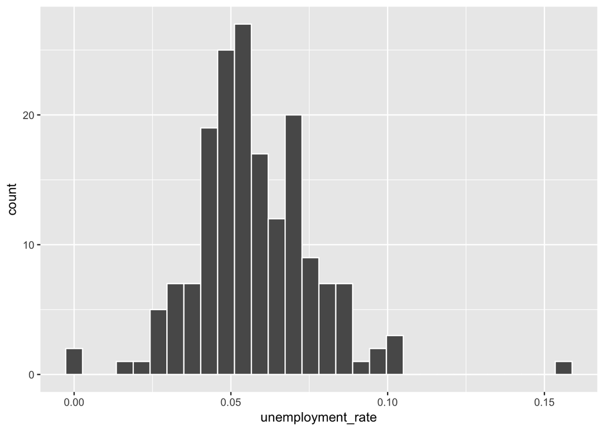

```r
library(fivethirtyeight)
ggplot(data = college_all_ages, mapping = aes(x = unemployment_rate)) +
  geom_histogram(color = "white")
```

```r
#glimpse(college_all_ages)
```

## Fixing an inappropriate plot for two variables

The last exercise showed the distribution of `unemployment_rate` across all majors. The first natural question that comes to mind is how the distribution varies while taking into account different categories of college majors. The plot shown below is one attempt at doing so, but has some major flaws. Your task is to produce a more appropriate plot after joining with another data frame to use a variable with fewer categories than `major_category`.

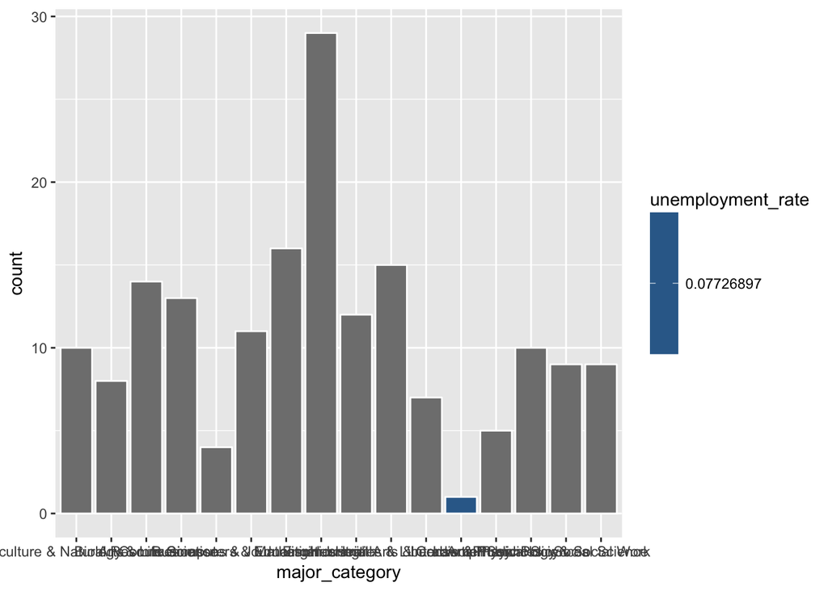

```r
ggplot(data = college_all_ages, aes(x = major_category, fill = unemployment_rate)) + geom_bar(color="white")
```

Instructions:

- Join with the divisions data frame to look-up the values of division for each of the values of `major_category` in `college_all_ages`. (You should print the divisions data frame in the Console to get a sense for how `major_category` levels were grouped in the division variable in the divisions data frame.)
- Give `college_with_divisions` as a name to this joined data frame.
- Write code to produce an appropriate plot looking at how `unemployment_rate` varies across division in the `college_with_divisions` data frame. Your plot should not involve a histogram in any way.

```r
# Make sure to load the needed packages!
library(fivethirtyeight)
library(ggplot2)
library(dplyr)

# where is that divisions dataframe??
# Join first to create data frame with a name of `college_with_divisions`
#college_with_divisions <- inner_join(x = college_all_ages, y = divisions, by = "major_category")
#glimpse(college_with_divisions)
#print(college_with_divisions)
# Now create an appropriate plot that is not related to a histogram
#ggplot(data = college_with_divisions, mapping = aes(x = divisions, y = unemployment_rate)) + geom_bar()
```

[output not shown]

## Fix the incorrect code

Recall the `bechdel` data frame you have worked with previously including the five-year time increments. (It should already be loaded in above.) Your friend is trying to produce the side-by-side barplot shown, but is having a really tough time and has made many mistakes in their code.

Instructions:

- Fix their code given to produce the plot shown.
- Note: the “{r}” was removed from the codeblock so that it doesn’t prevent you from kniting the file. Add the {r} back so that you can work on and run this part of the code.

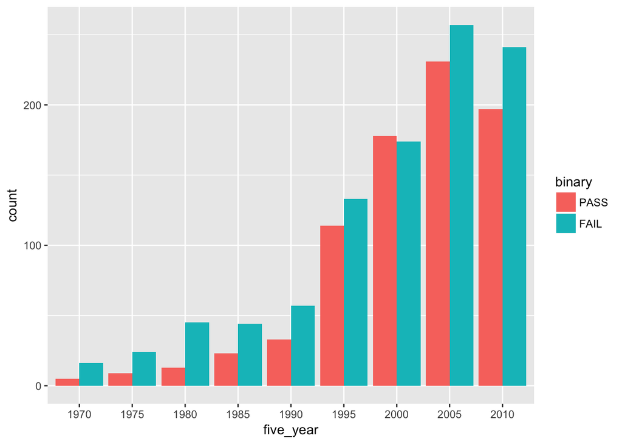

```
## What happened here?
```

```r
ggplot(data = bechdel, mapping = aes(x = five_year, fill = binary)) +
    geom_bar(position = "dodge")
```

We now shift our data set of interest to the flying data frame in the `fivethirtyeight` package. First, read the relevant 2014 article on FiveThirtyEight.com (https://fivethirtyeight.com/datalab/airplane-etiquette-recline-seat/). Next, carefully read over the documentation for flying via `?fivethirtyeight::flying` as well before you begin this problem to better understand what the variables represent. Note here that we use `na.omit(flying)` instead of flying to remove all of the rows with missing values in the data frame before plotting.

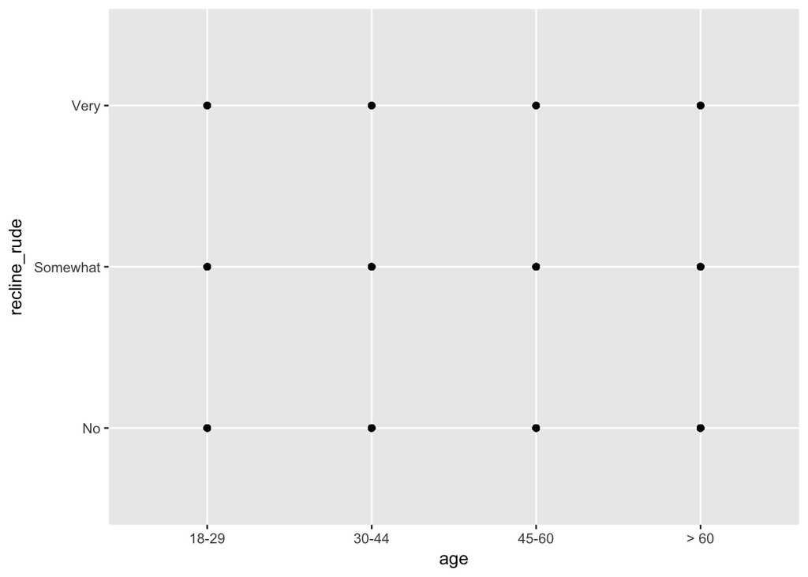

```r
cleanedFlying <- na.omit(flying)
ggplot(data = cleanedFlying, aes(x=age, y= recline_rude))+geom_point()
```

The plot that is given is not an appropriate plot for looking at the relationship between age and recline_rude. What would be the more appropriate plot?

Possible Answers: D (as age as well as recline_rude are both kind of categorical variables so its better to use stacked barplot. I guess, it might be even best choice than that of faceted histogram although it also quite looks convincing.)

1. Boxplot
2. Line graph
3. Faceted histogram
4. Stacked barplot

## Reverse engineer the barplot

Let’s create the appropriate plot referenced in the last exercise.

Instructions:

- Give the correct code needed to produce an appropriate plot based on the na.omit(flying) data frame derived from flying in the `fivethirtyeight` package.

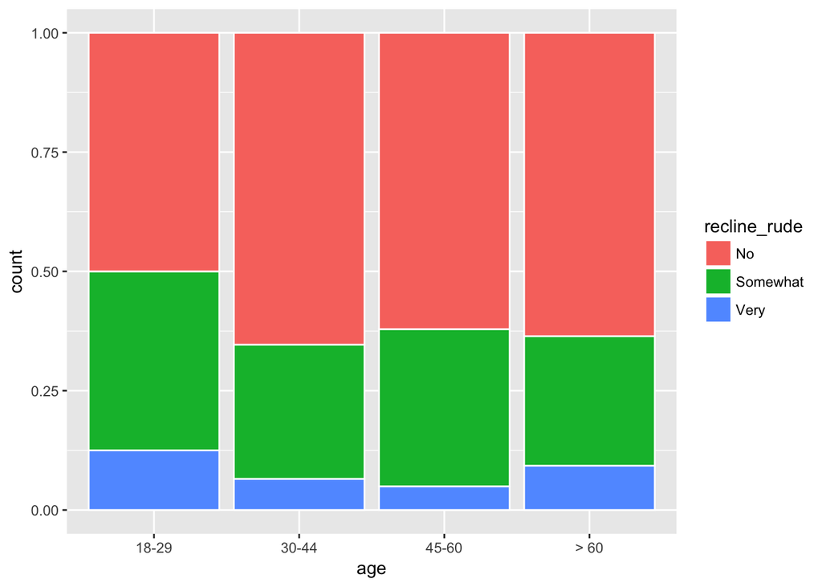

```r
ggplot(data = cleanedFlying, aes(x = age, fill = recline_rude)) +
        geom_bar(position = "fill", color = "white")
```